# Lab exercise, week 3 - numpy & matplotlib basics

Contents:

- Overview of numpy arrays
- Exercises for numpy
- Exercises for plotting

## NumPy - overview

Python lists are somewhat weird creatures. In contrast to basic array types in other languages like C# and Java, they can hold objects of different types and new elements can be inserted in the middle. NumPy arrays are much more like C# arrays - all elements have the same type.

```python
# by convention numpy is always imported as np
import numpy as np
```

### Common ways of creating numpy arrays

```python
a = np.array([5, 2, 17])  # Convert a Python list into a numpy array
a
```

```python
# List of lists gets converted into a 2D array
np.array([[5, 7, 2],
          [9, 4, 1]])
```

```python
np.arange(5)  # Same as Python's range() but creates a numpy array
```

```python
np.zeros(5)  # Create a numpy array with five elements, all set to zero
```

```python
c = np.ones(7)  # Create a numpy array with five elements, all set to 1
c
```

```python
# Array of 6 random numbers between 0 and 1
np.random.rand(6)
```

```python
# array with 6 random integers between 0 and 100 (not including 100 as usual)
np.random.randint(100, size=6)
```

### Array properties

```python
b = np.array([[5, 7, 2],
              [9, 4, 1]])
b
```

```python
# Data type of the array
a.dtype
```

```python
# number of dimensions
b.ndim
```

```python
# array shape is a Python tuple, in this case it's (2, 3) because b is a 2 by 3 array.
b.shape
```

```python
# The total number of elements
b.size
```

```python
# Note that zeros byt default uses the float64 data type
z = np.zeros(7)
z.dtype
```

```python
# But data type can be set explicitly, almost all numpy functions that create arrays take an optional dtype parameter
# Let's set it to an 8 bit integer
z = np.zeros(7, dtype=np.int8)
z.dtype
```

## Exercises

Read section 2.2 of the book (The Basics of NumPy Arrays) and complete the tasks below.

### Numpy Array Creation

##### Convert a list into a numpy array

```python
lst = [5, 3, 8, 4]
lst
```

```python
# your code here
x = np.array(lst)
x
```

#### What happens when you multiply a list by 3, what a about an array multiplied by 3?

```python
# Feel free to add more cells
lst_times3 = lst * 3
lst_times3
```

```python
arrTimes3 = x * 3
arrTimes3
```

#### Create an array of 10 ones [1, 1, 1, ... ]

```python
onesArr = np.ones(10)
onesArr
```

#### Create an array of 10 fives [5, 5, 5, .... ]

```python
fivesArr = np.ones(10) * 5
fivesArr
```

#### Create an array of the integers from 10 to 50 (including 50)

```python
arrRange = np.arange(10, 51)
arrRange
```

#### Create an array of 10 random numbers between 0 and 5

```python
arrRand = np.random.rand(10) * 5
arrRand
```

#### Read the help for np.linspace function and create an array of 11 evenly spaced elements between 0 and 2

use `np.linspace?` or `?np.linspace` to show the help

```python
np.linspace(0,2,11)
```

#### Create a 3 by 4 array of ones

```python
ones1 = np.ones((3,4))
print(ones1)
```

#### Create a 3 by 4 array of fives

```python
fives = np.ones((3,4)) * 5
print(fives)
```

### Array Indexing

Using the following arrays `a` and `m` for the questions below

```python
a = np.arange(10,21)
a
```

```python
m = np.arange(1,22).reshape((3,7))
print(m)
```

### Create an array containing...

#### the first 4 elements of a

```python
a1 = a[0:4]
a1
```

#### the last 3 elements of a

```python
a2 = a[-3:]
a2
```

#### The middle elements of a from 15 to 18 inclusive

```python
a3 = a[5:9]
a3
```

#### The first column of m

```python
m1 = m[:,0]
m1
```

#### The middle row of m

```python
m2 = m[1,:]
m2
```

#### The left 3 columns of m

```python
m3 = m[:,0:3]
print(m3)
```

#### The bottom-right 2 by 2 square

```python
m4 = m[1:3,-2:]
print(m4)
```

#### (bonus) every other element of a

```python
a4 = a[::2]
a4
```

### Array Math

#### Subtract 5 from each element of a

```python
a_minus5 = a - 5
a_minus5
```

#### Create an array containing squares of all numbers from 1 to 10 (inclusive)

```python
squaredArr = np.arange(1,11) ** 2
squaredArr
```

#### Create an array containing all powers of 2 from $2^0$ to $2^{10}$ (inclusive)

```python
poweredArr = 2 ** np.arange(0,11)
poweredArr
```

#### Same as above (powers of two), but subtract one from each element, that is $a_k = 2^k - 1$

```python
subPoweredArr = (2 ** np.arange(0,11)) - 1
subPoweredArr
```

### Bonus task

Write code that lists all available dtypes with specified number of bits

```python
# Hint
np.int8
```

## Plotting Basics

- Use [this tutorial](https://matplotlib.org/users/pyplot_tutorial.html) as reference when (if) you get stuck
- Execute the cells with imports, otherwise you won't have numpy and matplotlib imported and Python will complain

```python
import numpy as np
import matplotlib.pyplot as plt
```

```python
# Load weather data (take a look at that CSV file on GitHub or via Excel and note column names)
weather = np.loadtxt("OshawaWeather2016.csv", skiprows=1, delimiter=',')
```

```python
weather.shape
```

```python
weather.dtype
```

#### Crate separate 1D arrays for each column (e.g: day, maxt, mint and so on)

```python
# your code here
# column name in csv file: Day,Max Temp (°C),Min Temp (°C),Mean Temp (°C),Total Precip (mm)
# day = weather[???]
day = weather[:,0]
maxTemp = weather[:,1]
minTemp = weather[:,2]
meanTemp = weather[:,3]
totalPrecip = weather[:,4]
print(day)
#print(maxTemp)
#print(minTemp)
#print(meanTemp)
#print(totalPrecip)
```

#### Plot the minimum temperature as a function of day number

```python
plt.plot(day, minTemp)
```

#### Plot the max temperature in degrees Fahrenheit

```python
maxTempF = maxTemp * 9/5 + 32
plt.plot(day, maxTempF)
```

#### Plot the difference between the maximum and the minimum day temperature as a function of day number

```python
plt.plot(day, maxTemp - minTemp)
```

#### Plot both, the minimum and maximum temperature on the same figure

```python
plt.plot(day, minTemp, label='Min Temp (°C)')
plt.plot(day, maxTemp, label='Max Temp (°C)')
plt.legend()
plt.xlabel('Day of the year')
plt.ylabel('Temperature (°C)')
```

#### Add axis labels and a legend to the plot above

Use the following functions:

- plt.xlabel
- plt.ylabel
- plt.title
- plt.legend

#### Plot the precipitation as a function of max temperature

You probably don't want a line connecting the dots. Are there any patterns you can spot?

```python
plt.plot(maxTemp, totalPrecip, marker='o', linestyle='None')
plt.xlabel('Max Temperature (°C)')
plt.ylabel('Total Precipitation (mm)')
```

#### Plot the precipitation as a function of (t_max - t_min)

```python
plt.plot(maxTemp - minTemp, totalPrecip, marker='o', linestyle='None')
plt.xlabel('Max Temperature (°C)')
plt.ylabel('Total Precipitation (mm)')
```

#### Read about plt.hist() function and plot a histogram of the maximum temperatures

```python
plt.hist?
```

#### Plot a histogram of the differences between the min and max temperature

```python
plt.hist(maxTemp - minTemp, bins=45, edgecolor='black')
```

#### For each day calculate the average of the 3 temperatures in the data (min max and avg)

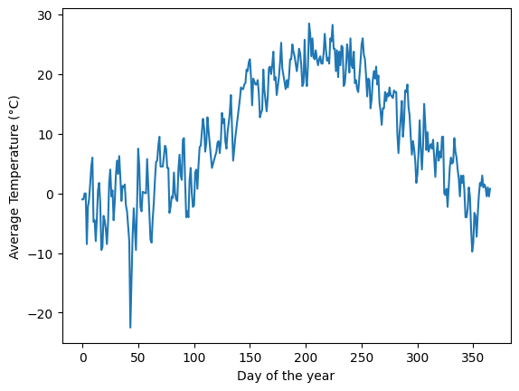

```python
plt.plot(day, (maxTemp + minTemp + meanTemp) / 3)
plt.xlabel('Day of the year')
plt.ylabel('Average Temperature (°C)')
```

#### Calculate the total amount of precipitation for the whole year

Does the number seem reasonable? The annual average precipitation in Toronto is 831 mm according to https://en.wikipedia.org/wiki/Geography_of_Toronto

```python
totalAnnualPrecip = np.sum(totalPrecip)
print(totalAnnualPrecip)
if totalAnnualPrecip > 831:
    print(f"{totalAnnualPrecip - 831} mm more than average precipitation in Toronto")
else:
    print(f"{831 - totalAnnualPrecip} mm less than average precipitation in Toronto")
```

```
662.8000000000001
168.19999999999993 mm less than average precipitation in Toronto
```

#### Calculate the total precipitation on all odd numbered days (day 1, 3, 5 and so on)

```python
totalOddDaysPrecip = np.sum(totalPrecip[::2])
print(totalOddDaysPrecip)
```

```
365.9
```